# T-testing the s*** out of your data

Riccardo Fusaroli

May 23, 2016

# Language in Depression

In this exercise, based on real data, we will explore whether depression is associated with a specific way of speaking.

### Structure of the exercise

- Loading the libraries
- Setting the directory and loading the data
- Look at the data (which variables are there?)
- What to look for:
- External validity (characteristics of the participants)
- Hypothesis driven exploration (plot the relevant variables)
- Visualize the data:
- Histograms (distribution)
- Scatterplots
- Barplot
- Boxplot
- Violinplot
- Quantitatively describe the data
- Mean
- SD
- Median
- Quartiles
- Let’s go after the hypotheses!
- Word count and depression
- Use of positive words and depression (plot + statistical summary)
- Use of negative words and depression (plot + statistical summary)
- Use of past tense and depression (plot + statistical summary)

### Loading the relevant libraries

Load necessary libraries : what will you need?

- e.g. something to plot with

```r
library (ggplot2)
```

### Define your working directory and load the data

- Create a new variable called locpath (localpath)
- Set it to be equal to your working directory
- Move to that directory (setwd(locpath))
- Load the data: “Day2Exercise1.csv” (use read.csv(fileName))

```r
getwd()
```

```
## [1] "/Users/semrf/Dropbox/My courses/2016 - stats for humanities/ExerciseR"
```

```r
locpath="/Users/semrf/Dropbox/My courses/2016 - stats for humanities/ExerciseR"
setwd(locpath)
Data <- read.csv("Day2Exercise1.csv")
```

### Visualize the dataset

Take a look at the data - look at the head (headers plus first 6 lines) - get number of rows, number of columns - look at one row, one column - look at one category (f.ex. diagnosis) - select all participant with a diagnosis

```r
print(head(Data))
```

```
##   nr gender  age education diagnosis hamD17 totalWords uniqueWords
## 1 k1      0 30.3      12.0         0      1       2848         517
## 2 k2      1 25.4      14.0         0      3       2451         466
## 3 k3      1 48.9      11.0         0      2       1516         344
## 4 k4      1 38.8      15.5         0      3       2861         566
## 5 k6      0 22.4      11.0         0      2       3319         557
## 6 k7      1 47.4      15.5         0      4       2332         465
##   pronouns pronounsPerc jegPerc2 jeg  jegPerc quant quantPerc verbs
## 1      182     6.390449 61.53846 112 3.932584    99  3.476124   355
## 2      247    10.077519 70.85020 175 7.139943    43  1.754386   320
## 3      167    11.015831 67.66467 113 7.453826    37  2.440633   193
## 4      208     7.270185 59.61538 124 4.334149    68  2.376791   363
## 5      282     8.496535 65.24823 184 5.543839    52  1.566737   401
## 6      236    10.120069 68.22034 161 6.903945    40  1.715266   321
##   verbsPerc pastVerbs pastVerbsPerc presentVerbs presentVerbsPerc positive
```

[output cut: 20 more lines]

```r
print(nrow(Data))
```

```
## [1] 30
```

```r
print(ncol(Data))
```

```
## [1] 31
```

```r
print(Data[1,])
```

```
##   nr gender  age education diagnosis hamD17 totalWords uniqueWords
## 1 k1      0 30.3        12         0      1       2848         517
##   pronouns pronounsPerc jegPerc2 jeg  jegPerc quant quantPerc verbs
## 1      182     6.390449 61.53846 112 3.932584    99  3.476124   355
##   verbsPerc pastVerbs pastVerbsPerc presentVerbs presentVerbsPerc positive
## 1  12.46489       103      3.616573          252         8.848315       34
##   positivePerc negative negativePerc cognitive cognitivePerc firstSing
## 1      1.19382        8    0.2808989         5     0.1755618       130
##   firstSingPerc firstPlural firstPluralPerc
## 1      4.564607          10       0.3511236
```

```r
print(Data[,1])
```

```
##  [1] k1  k2  k3  k4  k6  k7  k8  k9  k10 k11 k12 k13 k14 k15 k16 d1  d2
## [18] d3  d4  d5  d6  d7  d8  d9  d10 d11 d13 d14 d15 d16
## 30 Levels: d1 d10 d11 d13 d14 d15 d16 d2 d3 d4 d5 d6 d7 d8 d9 k1 ... k9
```

```r
print(Data$diagnosis)
```

```
##  [1] 0 0 0 0 0 0 0 0 0 0 0 0 0 0 0 1 1 1 1 1 1 1 1 1 1 1 1 1 1 1
```

```r
print(Data[Data$diagnosis==1,])
```

```
##     nr gender  age education diagnosis hamD17 totalWords uniqueWords
## 16  d1      1 22.1      12.0         1     23       3210         595
## 17  d2      0 21.1      10.0         1     29       2073         482
## 18  d3      1 29.3      11.0         1     25       1755         384
## 19  d4      1 25.1      13.0         1     22       2475         521
## 20  d5      0 38.6      17.0         1     22       2294         461
## 21  d6      0 31.0      13.0         1     19       4412         685
## 22  d7      0 29.7      11.0         1     19       1603         393
## 23  d8      1 46.2      15.5         1     34       3208         506
## 24  d9      1 37.8      15.5         1     16       2335         452
## 25 d10      1 24.5      14.0         1     21       4346         589
## 26 d11      1 24.5      13.0         1     23       2382         409
## 27 d13      1 22.1      13.0         1     19       2286         404
## 28 d14      1 47.3      12.5         1     19       3046         572
## 29 d15      1 30.4      13.0         1     20       2423         463
```

[output cut: 65 more lines]

### Make sure the variables are in the right format (e.g. numeric vs. factor)

In particular, pay attention to: - participant id - gender - diagnosis

```r
Data$nr=as.factor(Data$nr)
Data$diagnosis=as.factor(Data$diagnosis)
Data$gender=as.factor(Data$gender)
```

### Quantify the dataset

You can also get a quantitative overview over the different variables (Min, 1st Quartile, Median, Mean, 3rd Quartile, Max) using summary() and sd()

```r
print(summary(Data))
```

```
##        nr     gender      age          education     diagnosis
##  d1     : 1   0: 9   Min.   :21.10   Min.   :10.00   0:15
##  d10    : 1   1:21   1st Qu.:24.50   1st Qu.:12.00   1:15
##  d11    : 1          Median :30.40   Median :13.00
##  d13    : 1          Mean   :32.42   Mean   :13.14
##  d14    : 1          3rd Qu.:38.80   3rd Qu.:14.00
##  d15    : 1          Max.   :48.90   Max.   :17.00
##  (Other):24          NA's   :1       NA's   :1
##      hamD17        totalWords    uniqueWords       pronouns
##  Min.   : 0.00   Min.   :1405   Min.   :290.0   Min.   :131.0
##  1st Qu.: 1.25   1st Qu.:1923   1st Qu.:417.0   1st Qu.:189.2
##  Median :10.00   Median :2437   Median :465.5   Median :240.5
##  Mean   :11.90   Mean   :2517   Mean   :475.9   Mean   :249.6
##  3rd Qu.:21.75   3rd Qu.:2978   3rd Qu.:527.8   3rd Qu.:300.0
##  Max.   :34.00   Max.   :4412   Max.   :685.0   Max.   :516.0
##
##   pronounsPerc       jegPerc2          jeg           jegPerc
##  Min.   : 6.390   Min.   :50.34   Min.   : 75.0   Min.   :3.933
##  1st Qu.: 9.183   1st Qu.:62.30   1st Qu.:125.0   1st Qu.:5.789
##  Median : 9.802   Median :67.94   Median :169.5   Median :6.843
##  Mean   : 9.921   Mean   :67.14   Mean   :167.6   Mean   :6.671
##  3rd Qu.:10.661   3rd Qu.:71.32   3rd Qu.:183.5   3rd Qu.:7.428
##  Max.   :12.629   Max.   :80.62   Max.   :416.0   Max.   :9.572
##
##      quant         quantPerc          verbs         verbsPerc
##  Min.   :16.00   Min.   :0.7223   Min.   :179.0   Min.   :10.79
##  1st Qu.:27.25   1st Qu.:1.2252   1st Qu.:248.2   1st Qu.:12.45
##  Median :42.00   Median :1.5933   Median :320.5   Median :12.92
##  Mean   :42.23   Mean   :1.7317   Mean   :320.8   Mean   :12.85
##  3rd Qu.:52.00   3rd Qu.:1.8495   3rd Qu.:374.2   3rd Qu.:13.33
##  Max.   :99.00   Max.   :3.6299   Max.   :520.0   Max.   :14.65
##
##    pastVerbs      pastVerbsPerc    presentVerbs   presentVerbsPerc
##  Min.   : 43.00   Min.   :1.496   Min.   : 84.0   Min.   : 3.427
##  1st Qu.: 74.25   1st Qu.:2.831   1st Qu.:129.0   1st Qu.: 6.130
##  Median : 98.00   Median :4.449   Median :201.5   Median : 8.399
##  Mean   :114.47   Mean   :4.745   Mean   :206.3   Mean   : 8.108
##  3rd Qu.:148.50   3rd Qu.:6.182   3rd Qu.:263.5   3rd Qu.: 9.703
##  Max.   :236.00   Max.   :9.629   Max.   :436.0   Max.   :11.503
##
```

[output cut: 9 more lines]

```
##  Min.   : 3.00   Min.   :0.1709   Min.   :102.0   Min.   : 4.565
##  1st Qu.: 8.00   1st Qu.:0.3447   1st Qu.:151.0   1st Qu.: 7.326
##  Median :10.50   Median :0.4631   Median :214.5   Median : 8.390
##  Mean   :13.83   Mean   :0.5247   Mean   :212.8   Mean   : 8.441
##  3rd Qu.:18.75   3rd Qu.:0.6475   3rd Qu.:245.2   3rd Qu.: 9.484
##  Max.   :40.00   Max.   :1.2648   Max.   :487.0   Max.   :11.206
##
##   firstPlural    firstPluralPerc
##  Min.   : 4.00   Min.   :0.1651
##  1st Qu.: 7.25   1st Qu.:0.3752
##  Median :13.00   Median :0.4901
##  Mean   :16.13   Mean   :0.6361
##  3rd Qu.:19.25   3rd Qu.:0.7379
##  Max.   :64.00   Max.   :2.1213
##
```

```r
print(sd(Data$age,na.rm=TRUE))
```

```
## [1] 9.036173
```

### Let’s get to business - checking the participant sample

It’s important to get a feel for your data and plots are often the best way to do so.

First we want to check a few things:

- How many participants do we have? How many with a diagnosis? How many in the comparison group?
- What about age and gender? Are they equally represented in the data? and in the two groups?

#### We start with number of participants and by group

This is simple. Let’s just summarize the column diagnosis

```r
cdata <- aggregate(Data["nr"], by=Data[c("diagnosis")], FUN=length)
```

#### What about gender? In the whole sample and in each group

This is a bit tricky. We’re going to use a new function: aggregate

```r
cdata <- aggregate(Data["nr"], by=Data[c("diagnosis","gender")], FUN=length)
```

#### What about age? In the full sample and by diagnosis?

- Create the plot and specify the variables at stake
- Define which kind of plot
- Add text to the plot
- Calculate it (using aggregate)

What can we infer from the graph? And from the calculation?

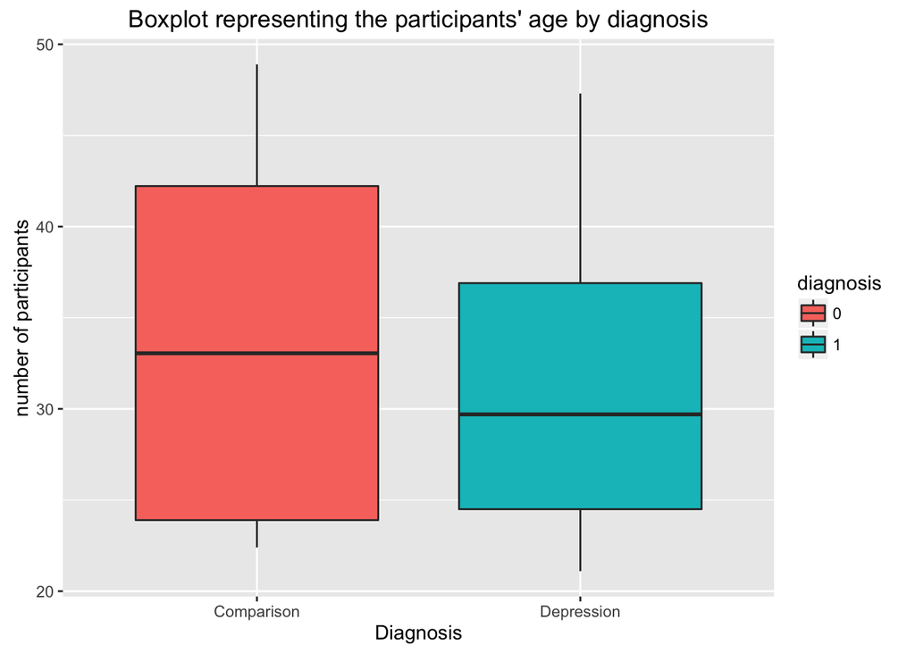

```r
plot2 <- ggplot(Data) + geom_boxplot(aes(x=diagnosis,y=age, fill=diagnosis)) +
          ggtitle("Boxplot representing the participants' age by diagnosis") +
          xlab("Diagnosis") +
          ylab("number of participants") +
          scale_x_discrete(labels=c("Comparison", "Depression"))
print(plot2)
```

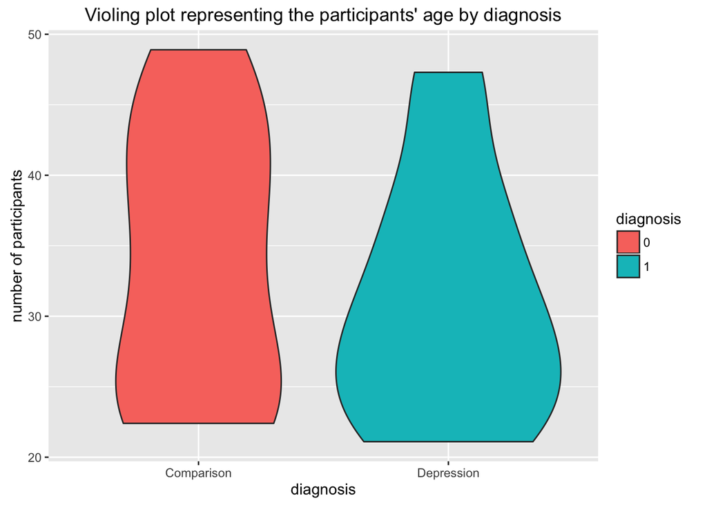

```r
plot3 <- ggplot(Data) + geom_violin(aes(x=diagnosis,y=age, fill=diagnosis)) +
          ggtitle("Violing plot representing the participants' age by diagnosis") +
          xlab("diagnosis") +
          ylab("number of participants") +
          scale_x_discrete(labels=c("Comparison", "Depression"))
print(plot3)
```

```r
aggregate(Data["age"], by=Data[c("diagnosis")], FUN=mean,na.rm=T)
```

```
##   diagnosis      age
## 1         0 33.89286
## 2         1 31.04667
```

```r
aggregate(Data["age"], by=Data[c("diagnosis")], FUN=sd,na.rm=T)
```

```
##   diagnosis      age
## 1         0 9.692302
## 2         1 8.478449
```

### From participants to relations: Total words used

Let’s try now to look at relations of data

So for example: do people with depression use less words than not depressed people?

#### Plotting

Let’s use a plot to check that out: - create a plot - define the relevant variables - define the kind of plot - add axes and text

What can you infer from the graph?

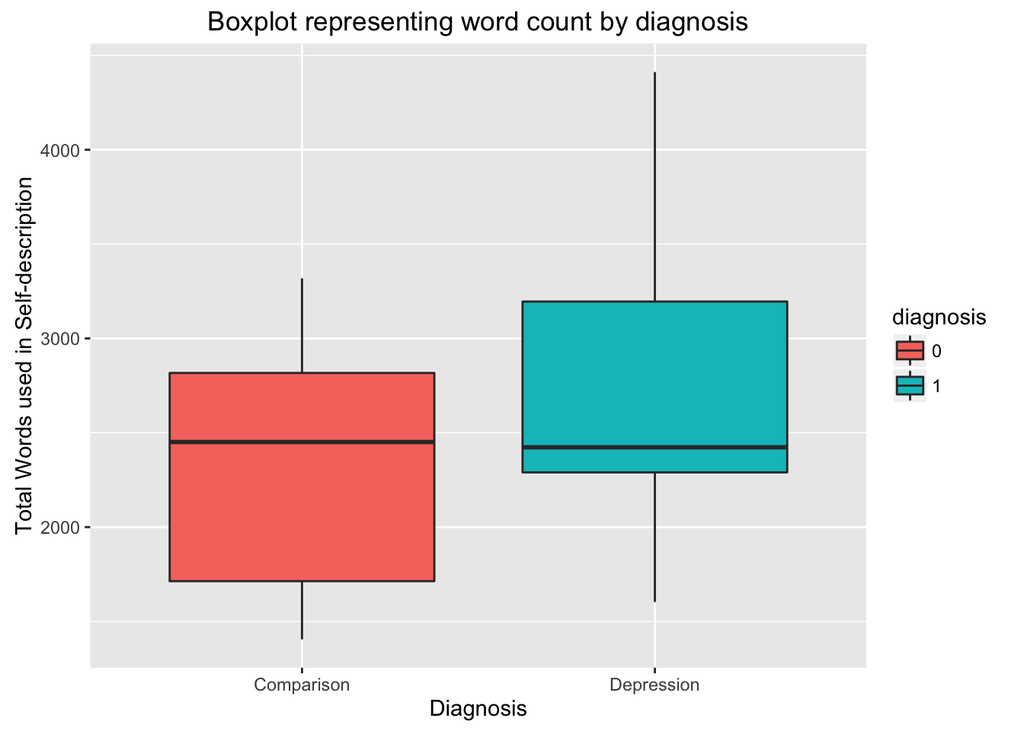

```r
depwordplot2 <- ggplot(Data, aes(x= diagnosis, y=totalWords, fill=diagnosis)) +
                geom_boxplot(outlier.colour = "red") +
                ggtitle ("Boxplot representing word count by diagnosis") +
                xlab("Diagnosis") +
                ylab("Total Words used in Self-description") +
                scale_x_discrete (labels=c("Comparison", "Depression"))

print(depwordplot2)
```

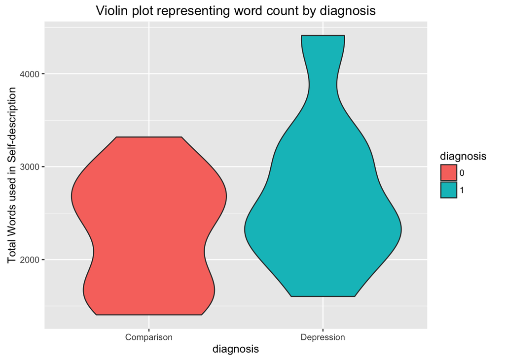

```r
depwordplot3 <- ggplot(Data, aes(x= diagnosis, y=totalWords, fill=diagnosis)) +
                geom_violin() +
                ggtitle ("Violin plot representing word count by diagnosis") +
                xlab("diagnosis") +
                ylab("Total Words used in Self-description") +
                scale_x_discrete (labels=c("Comparison", "Depression"))

print(depwordplot3)
```

#### Statistical testing

There seems to be a difference. But how big is it? And how likely is to see that difference if the null hypothesis were true?

```r
model1=lm(totalWords~diagnosis,Data)
summary(model1)
```

```
##
## Call:
## lm(formula = totalWords ~ diagnosis, data = Data)
##
## Residuals:
##     Min      1Q  Median      3Q     Max
## -1132.4  -548.2  -113.3   474.1  1676.6
##
## Coefficients:
##             Estimate Std. Error t value Pr(>|t|)
## (Intercept)   2298.2      189.4  12.136 1.14e-12 ***
## diagnosis1     437.2      267.8   1.632    0.114
## ---
## Signif. codes:  0 '***' 0.001 '**' 0.01 '*' 0.05 '.' 0.1 ' ' 1
##
## Residual standard error: 733.5 on 28 degrees of freedom
## Multiple R-squared:  0.0869, Adjusted R-squared:  0.05429
## F-statistic: 2.665 on 1 and 28 DF,  p-value: 0.1138
```

### From participants to relations: % of positive words

Let’s focus on more specific word usage: The % of positive words

#### Statistical testing

There seems to be a difference. But how big is it? And how likely is to see that difference if the null hypothesis were true?

```r
model1=lm(positivePerc~diagnosis,Data)
summary(model1)
```

```
##
## Call:
## lm(formula = positivePerc ~ diagnosis, data = Data)
##
## Residuals:
##      Min       1Q   Median       3Q      Max
## -0.72000 -0.22739 -0.00417  0.26387  0.66058
##
## Coefficients:
##             Estimate Std. Error t value Pr(>|t|)
## (Intercept)  1.41714    0.09774  14.499 1.52e-14 ***
## diagnosis1  -0.13044    0.13823  -0.944    0.353
## ---
## Signif. codes:  0 '***' 0.001 '**' 0.01 '*' 0.05 '.' 0.1 ' ' 1
##
## Residual standard error: 0.3785 on 28 degrees of freedom
## Multiple R-squared:  0.03082,    Adjusted R-squared:  -0.003791
## F-statistic: 0.8905 on 1 and 28 DF,  p-value: 0.3534
```

### From participants to relations: % of negative words

Let’s focus on more specific word usage: The % of negative words

#### Statistical testing

```r
model1=lm(negativePerc~diagnosis,Data)
summary(model1)
```

```
##
## Call:
## lm(formula = negativePerc ~ diagnosis, data = Data)
##
## Residuals:
##      Min       1Q   Median       3Q      Max
## -0.69829 -0.29512 -0.09803  0.16336  1.80324
##
## Coefficients:
##             Estimate Std. Error t value Pr(>|t|)
## (Intercept)   0.8302     0.1269   6.541 4.32e-07 ***
## diagnosis1   -0.0110     0.1795  -0.061    0.952
## ---
## Signif. codes:  0 '***' 0.001 '**' 0.01 '*' 0.05 '.' 0.1 ' ' 1
##
## Residual standard error: 0.4916 on 28 degrees of freedom
## Multiple R-squared:  0.000134,   Adjusted R-squared:  -0.03558
## F-statistic: 0.003754 on 1 and 28 DF,  p-value: 0.9516
```

### From participants to relations: % of past tense verbs

Let’s focus on more specific word usage: The % of past tense verbs

#### Statistical testing

There seems to be a difference. But how big is it? And how likely is to see that difference if the null hypothesis were true?

```r
model1=lm(pastVerbsPerc~diagnosis,Data)
summary(model1)
```

```
##
## Call:
## lm(formula = pastVerbsPerc ~ diagnosis, data = Data)
##
## Residuals:
##     Min      1Q  Median      3Q     Max
## -3.7963 -0.9005 -0.0860  1.1240  3.3881
##
## Coefficients:
##             Estimate Std. Error t value Pr(>|t|)
## (Intercept)   6.2406     0.4262  14.641 1.19e-14 ***
## diagnosis1   -2.9914     0.6028  -4.963 3.07e-05 ***
## ---
## Signif. codes:  0 '***' 0.001 '**' 0.01 '*' 0.05 '.' 0.1 ' ' 1
##
## Residual standard error: 1.651 on 28 degrees of freedom
## Multiple R-squared:  0.468,  Adjusted R-squared:  0.4489
## F-statistic: 24.63 on 1 and 28 DF,  p-value: 3.073e-05
```

### What’s next?

Is depression a yes/no diagnosis? What about severity of clinical features? [Tomorrow]

- Word count and depression severity
- Use of positive and depression severity (plot)
- Use of negative and depression severity (plot)
- Use of past tense and depression severity (plot)